# IrisSpeciesPredictor

Author

Tiffany Chu, Gaurang Ahuja, Nguyen Nguyen, Vienne Lee

## Summary

This project investigates whether iris species can be predicted using sepal and petal measurements. After loading and validating the dataset, we explore some basic patterns, do some EDA and then train a model. The overall results show that petal measurements provide strong separation between species, allowing the models to achieve high accuracy.

## Introduction

The Iris dataset is a well-known benchmark in machine learning, containing measurements of iris flowers collected to study how physical characteristics differ across species. This reseach is important as it reveals how petal/sepal measurements separate species, showing distinct patterns, enabling us to conduct further research into resource efficiency and interpretability in biological studies, botany, and related scientific work.

### Feature Summary

There are 4 numerical features in this dataset:

1. `sepal_length`: The length of the sepal (outer part of the flower)
2. `sepal_width`: The width of the sepal
3. `petal_length`: The length of the petal
4. `petal_width`: The width of the petal

There is 1 categorical feature in the dataset:

1. `species`: The target variable (label)

We are using the Iris dataset to answer the question: **“Can we predict the Iris species using petal and sepal measurements?”**

The data set contains 3 classes of 50 instances each, where each class refers to a type of iris plant. One class is linearly separable from the other 2; the latter are not linearly separable from each other (Fisher 1936).

## Methods & Results

Table 1: Preview of Iris Data

|  | sepal_length | sepal_width | petal_length | petal_width | species |
| --- | --- | --- | --- | --- | --- |
| 0 | 5.1 | 3.5 | 1.4 | 0.2 | setosa |
| 1 | 4.9 | 3.0 | 1.4 | 0.2 | setosa |
| 2 | 4.7 | 3.2 | 1.3 | 0.2 | setosa |
| 3 | 4.6 | 3.1 | 1.5 | 0.2 | setosa |
| 4 | 5.0 | 3.6 | 1.4 | 0.2 | setosa |

### Basic Data Stats

In the code below, we check some basic stats for the dataframe such as the number of rows, columns etc. We convert the columns names to a more standard format using underscores and lowercase. We then check how many unique species there are.

The training dataset has 104 rows and 5 columns.

### Data Wrangling

Table 2: Summary of numeric columns

|  | sepal_length | sepal_width | petal_length | petal_width |
| --- | --- | --- | --- | --- |
| count | 104.000000 | 104.000000 | 104.000000 | 104.000000 |
| mean | 5.833654 | 3.048077 | 3.777885 | 1.228846 |
| std | 0.772917 | 0.408877 | 1.670937 | 0.740726 |
| min | 4.400000 | 2.200000 | 1.000000 | 0.100000 |
| 25% | 5.100000 | 2.800000 | 1.600000 | 0.375000 |
| 50% | 5.800000 | 3.000000 | 4.400000 | 1.300000 |
| 75% | 6.400000 | 3.300000 | 5.000000 | 1.800000 |
| max | 7.700000 | 4.400000 | 6.900000 | 2.500000 |

Table 3: Feature variation per species of petal and sepal characteristics

| species | sepal_length mean | sepal_length std | sepal_width mean | sepal_width std | petal_length mean | petal_length std | petal_width mean | petal_width std |
| --- | --- | --- | --- | --- | --- | --- | --- | --- |
| setosa | 5.000000 | 0.336011 | 3.415625 | 0.400894 | 1.471875 | 0.163104 | 0.25625 | 0.113415 |
| versicolor | 6.000000 | 0.505863 | 2.832500 | 0.283194 | 4.297500 | 0.460483 | 1.35000 | 0.196116 |
| virginica | 6.459375 | 0.626748 | 2.950000 | 0.290717 | 5.434375 | 0.559729 | 2.05000 | 0.265184 |

#### Insights from Data Statistics

From the above tables, we can see:

- Most species have approximately the same number of observations
- Petal measurements display the strongest separation
- Setosa is distinct while versicolor and virginica show some overlap
- Petal dimensions have meaningful differences

## EDA Plots

Below are the plots visualize the underlying patterns, distributions, and relationships within the four features (`sepal_length`, `sepal_width`, `petal_length`, `petal_width`) in the Iris dataset. They each reveal the power of petal measurement for distinguishing species during classification. The boxplot shows how the species Setosa is easily distinguishable from just its petal measurements.

### Pairwise Plot

Pairwise plots show the relationships between feature pair and show any clusters. Figure 1 helps identify which pair of features show the clearest separation and allows us to identify which features are the most informative for prediction.

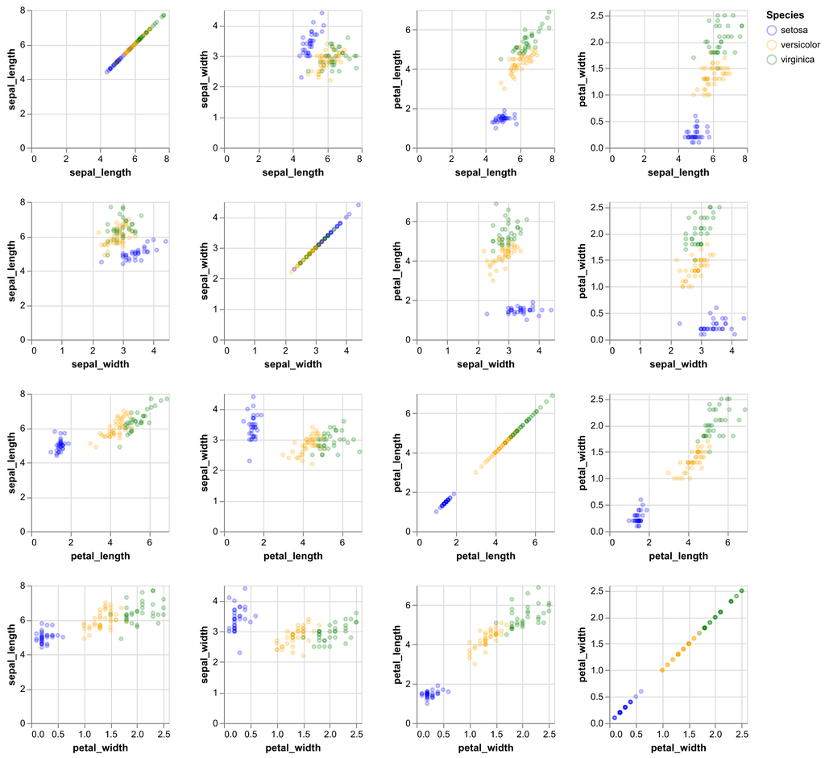

Figure 1: Pairwise Plot of Iris Features

### Boxplot

Figure 2 show how each feature varies across species. The median, spread, outliers, and overlaps helps identify features that are most predictive for classifying the Iris species.

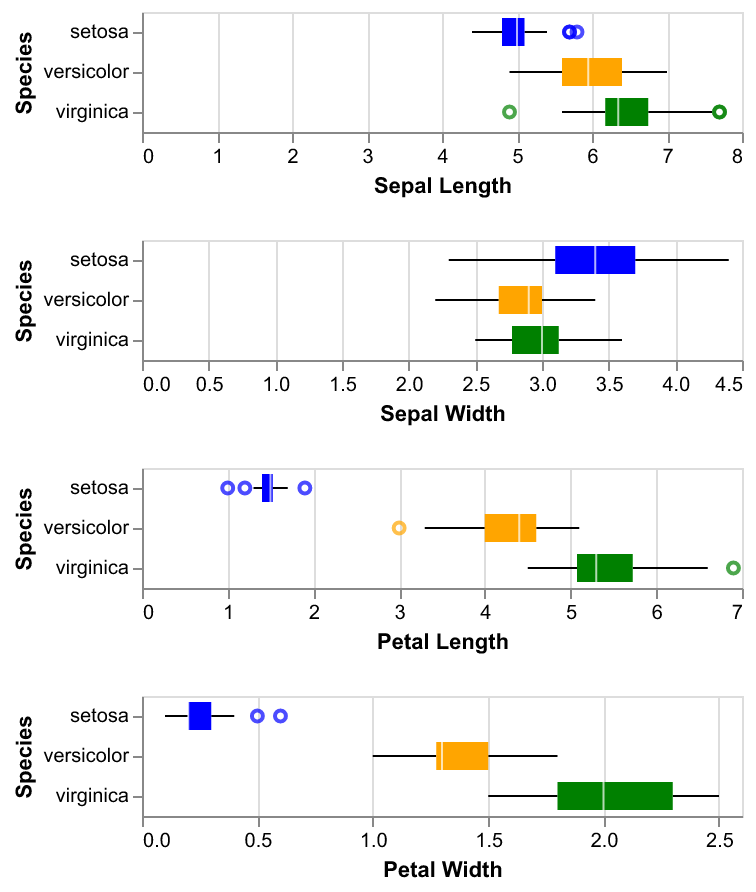

Figure 2: Boxplot of Iris Feature Variation

## Model Training Results

We tried 2 models, below are the results of each. This is after applying hyperparameter optimization to find the best `max_depth` and `n_neighbours` values. The cross-validation results show that Decision Trees with `max_depth` values from 4 to 18 fit the training data best while achieving high validation accuracy (94.3%) on unseen folds. While in the KNN hyperparameter tuning, findings show that choosing `n_neighbors` between 4 and 12 outputs a classification accuracy around 97% on cross-validation test scores.

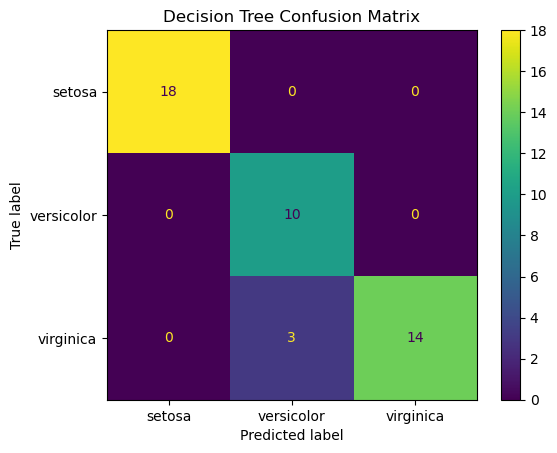

Figure 3: Decision Tree Confusion Matrix

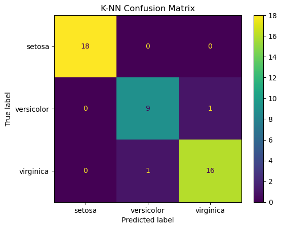

Figure 4: K-NN Confusion Matrix

## Discussion and Analysis

In our investigation of the Iris dataset, we establish whether these features are strong predictors for Iris species classification and rank their predictive power. This discussion begins with the insights derived from our in-depth exploratory data analysis, then the outcomes of our machine learning models, and finally exploring the implications for biological classification and machine learning practices for future research.  
To summarize the data, the Iris dataset consists of 150 samples with measurements for four features: sepal length, sepal width, petal length, and petal width, across three evenly distributed species: Setosa, Versicolor, and Virginica.

In our exploratory data analysis (EDA), the summary statistics in Table 2 and Table 3 show that petal measurements (length and width) exhibit more obvious differences across species compared to sepal feature measurements. Sepal measurements are not as varied across species and thus provide weaker separation when distinguishing species. Our visualizations of pairwise feature plots in Figure 1, and boxplots in Figure 2 confirm these patterns, they each reveal the power of petal measurement for distinguishing species during classification. Specifically, the boxplot shows how the species Setosa is easily distinguishable from just its petal measurements.

The findings that petal measurements strongly separate iris species and have high model accuracy are expected and align with prior knowledge and research on the Iris dataset. The petal length and width consistently show clearer distinctions among the species, particularly separating Setosa from Versicolor and Virginica, however, Sepal measurements tend to show more overlap and offer weaker discriminatory power.

However, there are some limitations associated with our study, some key limitations of the dataset and the related findings include: The dataset contains only 150 samples with 4 numeric features and 3 species classes, which is considered quite small and simple compared to data on other plant species. This limits the complexity of patterns that can be learned and makes it less applicable to more complex classification tasks. Its size also prevents it from being useful for complex machine learning techniques like deep learning, which require larger datasets.

Only sepal and petal measurements are considered, and other potentially informative features such as genetic data, environmental variables, or flower color are not recorded as features in the data. This constrains prediction to specific traits and may limit generalizability to other flowers or datasets.

It appears that the species Setosa is clearly separable, while Versicolor and Virginica show overlap in some measurements, leading to some classification errors and ambiguity that models must handle or risk making errors. The dataset is clean with no missing values or measurement noise, which is not typical/normal in many real datasets. This means models trained here may be optimistic compared to actual real world performance. So while appropriate for demonstrating classification approaches and feature importance, the Iris dataset’s limitations prevent our model from being broadly applicable and generalizable, which must be considered when interpreting and generalizing findings. We must also note that these methods are derived from the following sources: Pedregosa et al. (2025), UBC Master of Data Science Program (2025a), UBC Master of Data Science Program (2025b), UBC Master of Data Science Program (2025c), and errors from these sources may translate into our research.

The impact of these findings is significant in practical feature selection for machine learning. They show the importance of choosing the most informative features for classification tasks, improving model performance and simplifying models by focusing on fewer but more relevant measurements. This can aid in resource efficiency and interpretability in biological studies, botany, and related scientific work.

This brings up future questions that could use further research:

- How do more advanced machine learning algorithms (e.g., SVM) compare in classification accuracy using petal vs sepal features?
- Can combining petal and sepal features with additional biological or environmental data improve model robustness or reveal deeper insights?
- How well do these findings generalize to other flower species or datasets—can similar feature importance patterns be found?
- Could unsupervised learning reveal new subgroups or variations in iris species beyond the three classical ones using these or other features?

In summary, these findings are expected and show the predictive importance of petal dimensions in iris classification. They have implications for feature selection and model design, and point to further possible research on flower classification and its related biological questions

## References

Fisher, R. A. 1936. “Iris Dataset.” UCI Machine Learning Repository. https://archive.ics.uci.edu/dataset/53/iris.

Pedregosa, F., G. Varoquaux, A. Gramfort, V. Michel, B. Thirion, O. Grisel, M. Blondel, et al. 2025. *Scikit-Learn: Machine Learning in Python*. https://scikit-learn.org/stable/.

UBC Master of Data Science Program. 2025a. “DSCI 531: Visualization for Data Science – Course Notes.” UBC GitHub Pages. https://pages.github.ubc.ca/mds-2025-26/DSCI_531_viz-1_students/.

———. 2025b. “DSCI 571: Supervised Learning 1 – Course Notes.” UBC GitHub Pages. https://pages.github.ubc.ca/mds-2025-26/DSCI_571_sup-learn-1_students/.

———. 2025c. “DSCI 573: Feature and Model Selection – Course Notes.” UBC GitHub Pages. https://pages.github.ubc.ca/mds-2025-26/DSCI_573_feat-model-select_students/.